# DataCamp Financial Trading in R

Working notes for following allong with the [DataCamp Financial Trading in R](https://campus.datacamp.com/courses/financial-trading-in-r/) course.

```r
library(quantstrat)
library(IKTrading)
#library(tidyverse)
options("getSymbols.auto.assign" = FALSE)
options("getSymbols.warning4.0" = FALSE)
```

# Chapter 1 - Trading Basics

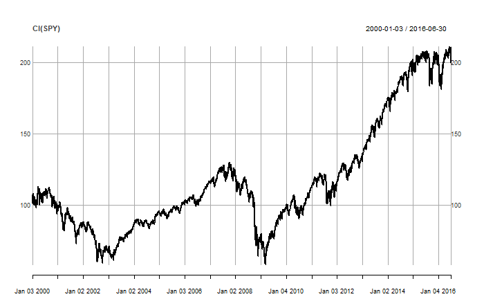

```r
# Get SPY from Yahoo Finance ("yahoo")
SPY <- getSymbols("SPY", from = "2000-01-01", to = "2016-06-30", src =  "yahoo", adjust =  TRUE)
# Plot the closing price of SPY
plot(Cl(SPY))
```

Add the SMA

The 200-day SMA is appproximately 10 months (200 business days, not including holidays & weekends)

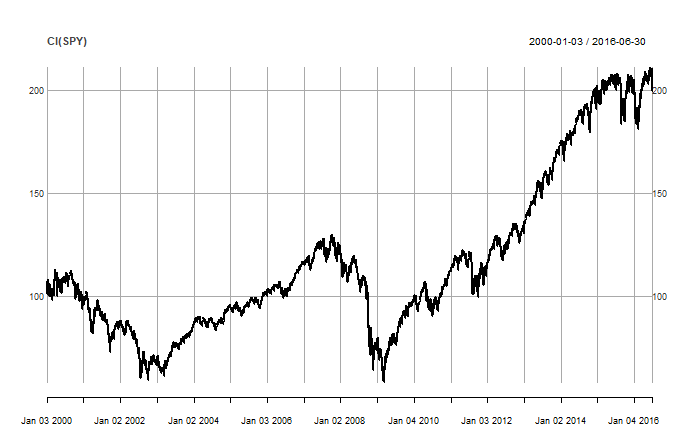

```r
plot(Cl(SPY))
```

[figure not shown]

```r
add_TA(SMA(Cl(SPY), n =200), col = "red")
```

# Chapter 2 - Boilerplate

All strategies need three dates (YYYY-MM-DD) - initialization date - from date - to date

Environment timezone

Currency Tell quanstrat which currency to use USD

Financial Data Via `getSymbols`

Create the equity. This tells quanstrat to use this instrument for simulation, rather than creating minimum buy sizes (as exist for futures). It also sets the currency for the specific instrument. Via `stock()`

Hierarchy - Account - Portfolio - Strategy

```r
portfolio.st <- strategy.st <- account.st <- "datacamp"
```

tradesize - size of initial trade initeq - total initial equity tradesize should not be larger thatn initeq

```r
tradesize <- 100000
initeq <- 100000
initdate <- "2000-01-01"
```

Once a strategy is run, it cannot be re-run. It must be removed via `rm.strategy` before running it again.

## Initialization process

1. Initialize the portfolio involves given it the name, the equities that are part of the portfolio, and the initializion date.
2. Initialize the accounts
3. Initialize Orders
4. Initialize the strategy

```r
# initialize the portfolio
initPortf(portfolio.st, symbols = "SPY", initDate = initdate, currency = "USD")
```

```
[1] "datacamp"
```

```r
# initialize the account
initAcct(account.st, portfolios = portfolio.st, initDate = initdate,
         currency = "USD", initEq = initeq)
```

```
[1] "datacamp"
```

```r
# initialize the orders
initOrders(portfolio.st, initDate = initdate)
# store the strategy
strategy(strategy.st, store = TRUE)
```

# Chapter 3 - Intro to Indicators

Indicators always operate on the `mktdata` internal data set, which will be updated with whatever instrument prices ultimately get passed in for backtesting.

RSI - Relative Strength Indicators

Create a standard 200-day SMA

```r
# Add a 200-day simple moving average indicator to your strategy
add.indicator(strategy = strategy.st,

              # Add the SMA function
              name = "SMA",

              # Create a lookback period
              arguments = list(x = quote(Cl(mktdata)), n = 200),

              # Label your indicator SMA200
              label = "SMA200")
```

```
[1] "datacamp"
```

Also create a faster (50-day) SMA. This combination of a smoother (laggier) and more volitale (more responsive) indicators is common.

```r
# Add a 50-day simple moving average indicator to your strategy
add.indicator(strategy = strategy.st,

              # Add the SMA function
              name = "SMA",

              # Create a lookback period
              arguments = list(x = quote(Cl(mktdata)), n = 50),

              # Label your indicator SMA200
              label = "SMA50")
```

```
[1] "datacamp"
```

Create a 3-day RSI

```r
# add an RSI 3 indicator to your strategy
add.indicator(strategy = strategy.st,

              # add an RSI function to your strategy
              name = "RSI",

              # use a lookback period of 3 days
              arguments = list(price = quote(Cl(mktdata)), n = 3),

              # label it RSI_3
              label = "RSI_3")
```

```
[1] "datacamp"
```

using `applyIndicators` to verify that indicators are working correctly

```r
applyIndicators(strategy.st, SPY)
```

[output not shown]

[output cut: 58 more lines]

[output not shown]

Creating custom indicator.

Example of creating a custom function and using it to build an indicator

```r
# Write the RSI_avg function
RSI_avg <- function(price, n1, n2) {

  # RSI 1 takes an input of the price and n1
  rsi_1 <- RSI(price = price, n = n1)

  # RSI 2 takes an input of the price and n2
  rsi_2 <- RSI(price = price, n = n2)

  # RSI_avg is the average of rsi_1 and rsi_2
  RSI_avg <- (rsi_1 + rsi_2)/2

  # Your output of RSI_avg needs a column name of "RSI_avg"
  colnames(RSI_avg) <- "RSI_avg"
  return(RSI_avg)
}
# Add the RSI_avg function to your strategy using an n1 of 3 and an n2 of 4, and label it "RSI_3_4"
add.indicator(strategy.st, name = "RSI_avg", arguments = list(price = quote(Cl(mktdata)), n1 = 3, n2 = 4), label = "RSI_3_4")
```

```
[1] "datacamp"
```

DVO - David Varadi Oscillator

```r
# Declare the DVO function. The first argument is the high, low, and close of market data.
DVO <- function(HLC, navg = 2, percentlookback = 126) {

  # Compute the ratio between closing prices to the average of high and low
  ratio <- Cl(HLC)/((Hi(HLC) + Lo(HLC))/2)

  # Smooth out the ratio outputs using a moving average
  avgratio <- SMA(ratio, n = navg)

  # Convert ratio into a 0-100 value using runPercentRank function
  out <- runPercentRank(avgratio, n = percentlookback, exact.multiplier = 1) * 100
  colnames(out) <- "DVO"
  return(out)
}
```

Apply the DVO

```r
# add the DVO indicator to your strategy
add.indicator(strategy = strategy.st, name = "DVO",
              arguments = list(HLC = quote(HLC(mktdata)), navg = 2, percentlookback = 126),
              label = "DVO_2_126")
```

```
[1] "datacamp"
```

```r
# use applyIndicators to test out your indicators
test <- applyIndicators(strategy = strategy.st, mktdata = OHLC(SPY))
# subset your data between Sep. 1 and Sep. 5 of 2013
test_subset <- test["2013-09-01/2013-09-05"]
```

# Chapter 4 - Signals

Signals are the interaction of market data with indicators. Events that it may be time to buy/sell an asset.

`add.signal` function takes: - strategy name - name of the function - argument to the function - label to the signal

Similar to the `apply` family.

Four types of signals:

1. sigComparison - relationship between two indicators (usually used as a filter for other signals)
2. sigCrossover - returns 1 on the first occurance (usually used more directly as a buy/sell signal) Fires once and then not again
3. sigThreshold - Compares range-bound indicator to a static quantity
1. `cross = TRUE` like sigCrossover
2. `cross = FALSE` like sigComparison
4. sigFormula - Complicated custom formula

comparison relationships

- gt - Greater than
- gte - Greater than or equal
- lt - less than
- lte - Less than or equal

```r
# add a sigComparison which specifies that SMA50 must be greater than SMA200, call it longfilter
add.signal(strategy.st, name = "sigComparison",

           # we are interested in the relationship between the SMA50 and the SMA200
           arguments = list(columns = c("SMA50", "SMA200"),

                            # particularly, we are interested when the SMA50 is greater than the SMA200
                            relationship = "gt"),

           # label this signal longfilter
           label = "longfilter")
```

```
[1] "datacamp"
```

```r
# add a sigCrossover which specifies that the SMA50 is less than the SMA200 and label it filterexit
add.signal(strategy.st, name = "sigCrossover",

           # we're interested in the relationship between the SMA50 and the SMA200
           arguments = list(columns = c("SMA50", "SMA200"),

                            # the relationship is that the SMA50 crosses under the SMA200
                            relationship = "lt"),

           # label it filterexit
           label = "filterexit")
```

```r
# implement a sigThreshold which specifies that DVO_2_126 must be less than 20, label it longthreshold
add.signal(strategy.st, name = "sigThreshold",

           # use the DVO_2_126 column
           arguments = list(column = "DVO_2_126",

                            # the threshold is 20
                            threshold = 20,

                            # we want the oscillator to be under this value
                            relationship = "lt",

                            # we're interested in every instance that the oscillator is less than 20
                            cross = FALSE),

           # label it longthreshold
           label = "longthreshold")
```

```
[1] "datacamp"
```

```r
# add a sigThreshold signal to your strategy that specifies that DVO_2_126 must cross above 80 and label it thresholdexit
add.signal(strategy.st, name = "sigThreshold",

           # reference the column of DVO_2_126
           arguments = list(column = "DVO_2_126",

                            # set a threshold of 80
                            threshold = 80,

                            # the oscillator must be greater than 80
                            relationship = "gt",

                            # we are interested only in the cross
                            cross = TRUE),

           # label it thresholdexit
           label = "thresholdexit")
```

```
[1] "datacamp"
```

Creating a test data set

```r
# Create your dataset: test
test_init <- applyIndicators(strategy.st, mktdata = OHLC(SPY))
test <- applySignals(strategy = strategy.st, mktdata = test_init)
```

```r
# add a sigFormula signal to your code specifying that both longfilter and longthreshold must be TRUE, label it longentry
add.signal(strategy.st, name = "sigFormula",

           # specify that longfilter and longthreshold must be TRUE
           arguments = list(formula = "longfilter & longthreshold",

                            # specify that cross must be TRUE
                            cross = TRUE),

           # label it longentry
           label = "longentry")
```

```
[1] "datacamp"
```

# Chapter 5 - Rules

Rules - function to create a transaction based upon a signal

Two types

- Enter rules - buying into a position
- Exit rules - selling a position

Orderqty (int or `all`) odertype (market, limit, other. Almost always market for common strategies) orderside (long or short) long for typical buys, unless you’re shorting stocks

replace (TRUE, if all other signals for this day canceled once this rule is triggers) prefer (when to place the trade, “Open” or “Close”)

```r
# fill in the rule's type as exit
add.rule(strategy.st, name = "ruleSignal",
         arguments = list(sigcol = "filterexit", sigval = TRUE, orderqty = "all",
                        ordertype = "market", orderside = "long",
                        replace = FALSE, prefer = "Open"),
         type = "exit")
```

```
[1] "datacamp"
```

```r
# fill in the replace argument in add.rule()
add.rule(strategy.st, name = "ruleSignal",
         arguments = list(sigcol = "thresholdexit", sigval = TRUE, orderqty = "all",
                        ordertype = "market", orderside = "long",
                        replace = FALSE, prefer = "Open"),
         type = "exit")
```

```
[1] "datacamp"
```

```r
# create an entry rule of 1 share when all conditions line up to enter into a position
add.rule(strategy.st, name = "ruleSignal",

         # use the longentry column as the sigcol
         arguments = list(sigcol = "longentry",

                        # set sigval to TRUE
                        sigval = TRUE,

                        # set orderqty to 1
                        orderqty = 1,

                        # use a market type of order
                        ordertype = "market",

                        # take the long orderside
                        orderside = "long",

                        # do not replace other signals
                        replace = FALSE,

                        # buy at the next day's opening price
                        prefer = "Open"),

         # this is an enter type rule, not an exit
         type = "enter")
```

```
[1] "datacamp"
```

```r
# add a rule that uses an osFUN to size an entry position
add.rule(strategy = strategy.st, name = "ruleSignal",
         arguments = list(sigcol = "longentry", sigval = TRUE, ordertype = "market",
                          orderside = "long", replace = FALSE, prefer = "Open",

                          # use the osFUN called osMaxDollar
                          osFUN = osMaxDollar,

                          # the tradeSize argument should be equal to tradesize (defined earlier)
                          tradeSize = tradesize,

                          # the maxSize argument should be equal to tradesize as well
                          maxSize = tradesize),
         type = "enter")
```

# Chapter 6 - Analyzing Your Strategy

apply you strategy - `applyStrategy` based upon you strategy and Update your porfolio - `updatePortf` - get the date range of the portfolio, subtracting out the initialDate `daterange <- time(getPortfolio(portfolio.st)$summary)[-1]` Update the account - `updateAcct` acct, daterange - `updateEndEq` acct Get trade stats - `tradeStates(Portfolios = portfolio.st)

```r
# use applyStrategy() to apply your strategy. Save this to out
out <- applyStrategy(strategy = strategy.st, portfolios = portfolio.st)
```

[output not shown]

```r
# Get the tradeStats for your portfolio
tstats <- tradeStats(Portfolios = portfolio.st)

# Print the profit factor
tstats$Profit.Factor
```

[output not shown]

```r
chart.Posn(Portfolio = portfolio.st, Symbol = "SPY")
```

[output not shown]

Sharpe ratio - ratio of reward to risk `PortfReturns(account.st)`